# CMSC/LING/STAT 208: ML - Homework 4

## Question 2

For this question, you will work with the **Boston** dataset. Load the dataset using the following code.

```r
library(ISLR2)  # load library

data("Boston")   # load dataset
```

The dataset contains information on housing from Boston suburbs. Consider `medv` (median value of owner-occupied homes in $1000s) as the response variable and `dis` (weighted mean of distances to five Boston employment centres) as the predictor. A scatterplot of the variables is shown below.

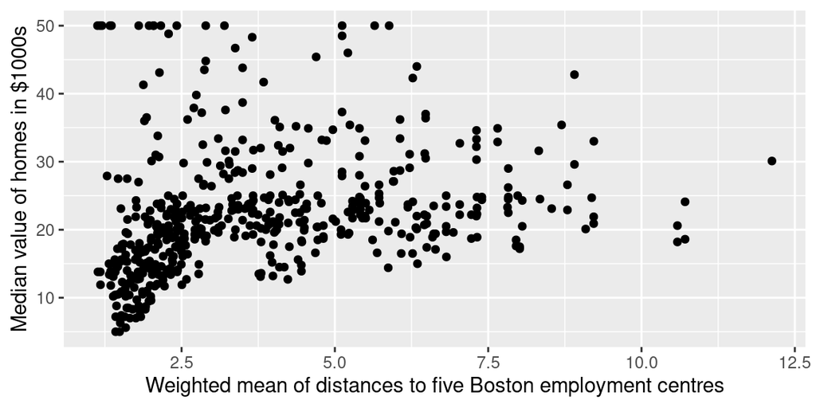

The objective is to compare the performance (in terms of RMSE) of the following models using CV.

- An SLR model with `dis` as the predictor;
  $$\widehat{\text{medv}} = \beta_0 + \left(\beta_1
  \times \text{dis}\right)$$
- A quadratic (second degree) polynomial model;
  $$\widehat{\text{medv}} = \beta_0 + \left(\beta_1
  \times \text{dis}\right) + \left(\beta_2 \times
  \text{dis}^2\right)$$
- A KNN regression model between `medv` and `dis` with optimal $K$ chosen by CV. Consider a grid of possible $K$ values from $1, 2, \ldots, 100$.

**Perform the following tasks.**

- Split the data into training and test sets (consider a 70-30 split).

```r
# write your R code here
set.seed(2084)

train_index2 <- createDataPartition(y = Boston$medv, p = 0.7, list = FALSE)

Boston_train <- Boston[train_index2,]

Boston_test <- Boston[-train_index2,]
```

- Implement 10-fold CV repeated 5 times for each of the models above. Use `metric = "RMSE"` and the appropriate `method`.

```r
# write your R code here
set.seed(2084)

cv_specs_kcv2 <- trainControl(method = "repeatedcv",
                             number = 10,
                             repeats = 5)

M1 <- train(form =  medv ~ dis,
            data = Boston_train,
            method = "lm",
            trControl = cv_specs_kcv2,
            metric = "RMSE")

M2 <- train(form = medv ~ poly(dis, degree = 2),
            data = Boston_train,
            method = "lm",
            trControl = cv_specs_kcv2,
            metric = "RMSE")

k_grid <- expand.grid(k = seq(1, 100, by = 1))

M3 <- train(form = medv ~ dis,
            data = Boston_train,
            method = "knn",
            trControl = cv_specs_kcv2,
            tuneGrid = k_grid,
            metric = "RMSE")
```

- Report the CV RMSE’s of the models above. Which model performs the best? If the KNN model shows the best performance, report the optimal value of $K$ and the corresponding RMSE.

```r
M1$results$RMSE
```

```
## [1] 8.693906
```

```r
M2$results$RMSE
```

```
## [1] 8.569156
```

```r
M3$results$RMSE
```

```
##   [1] 10.920244 10.135775  9.502591  9.190487  8.885098  8.768604  8.725945
##   [8]  8.617100  8.569368  8.531412  8.533908  8.510812  8.542816  8.528676
##  [15]  8.488529  8.455997  8.430287  8.434116  8.416140  8.400180  8.378742
##  [22]  8.370836  8.347777  8.350389  8.337968  8.341587  8.349831  8.341267
##  [29]  8.347772  8.328729  8.335437  8.325996  8.323733  8.321692  8.325360
##  [36]  8.323144  8.326427  8.324564  8.324695  8.328971  8.322617  8.321648
##  [43]  8.323985  8.319024  8.323393  8.324793  8.325792  8.325547  8.329822
##  [50]  8.328478  8.323664  8.313281  8.305657  8.295587  8.289864  8.293841
##  [57]  8.289972  8.289139  8.290126  8.290745  8.285839  8.283869  8.284486
##  [64]  8.282542  8.281748  8.285087  8.283545  8.281935  8.281280  8.277581
##  [71]  8.273590  8.271806  8.273551  8.275864  8.279997  8.280696  8.284976
##  [78]  8.279086  8.278976  8.281356  8.281643  8.283552  8.285172  8.288860
##  [85]  8.292913  8.296817  8.302331  8.304781  8.306699  8.313014  8.319457
##  [92]  8.324005  8.330590  8.331694  8.333847  8.335479  8.337608  8.339627
##  [99]  8.344088  8.348524
```

```r
M3
```

```
## k-Nearest Neighbors
##
## 356 samples
##   1 predictor
##
## No pre-processing
## Resampling: Cross-Validated (10 fold, repeated 5 times)
## Summary of sample sizes: 320, 321, 320, 321, 321, 320, ...
## Resampling results across tuning parameters:
##
##   k    RMSE       Rsquared    MAE
##     1  10.920244  0.11234328  7.636393
##     2  10.135775  0.08989971  7.290948
##     3   9.502591  0.10576771  7.004162
##     4   9.190487  0.11278367  6.748353
```

[output cut: 99 more lines]

```
Model 3 seems to have the lowest RMSE values and performs the best. The optimal value of k is 72 and its corresponding RMSE is 8.271806.
```

- Finally, with the optimal model, obtain predictions on the test data. Calculate and report the test set RMSE.

```r
final_model_preds2 <- predict(M3, newdata = Boston_test)

pred_error_est2 <- sqrt(mean((Boston$medv - final_model_preds)^2))

pred_error_est2
```

[output not shown]